# Airbnb Problem Definition

## Using the data without outliers

### Prepare the data

```python
# Drop review_ratings column as it does not have a good correlation
```

```python
df_withoutoutliers.info()
```

```
<class 'pandas.core.frame.DataFrame'>
Int64Index: 50033 entries, 0 to 74110
Data columns (total 10 columns):
 #   Column               Non-Null Count  Dtype
---  ------               --------------  -----
 0   room_type            50033 non-null  category
 1   accommodates         50033 non-null  float64
 2   bathrooms            50033 non-null  float64
 3   cancellation_policy  50033 non-null  category
 4   cleaning_fee         50033 non-null  category
 5   instant_bookable     50033 non-null  category
 6   review_score_log     50033 non-null  float64
 7   bedrooms             50033 non-null  float64
 8   beds                 50033 non-null  float64
 9   log_price            50033 non-null  float64
dtypes: category(4), float64(6)
memory usage: 2.9 MB
```

```python
df_withoutoutliers.drop('review_score_log',axis=1)
```

|  | room_type | accommodates | bathrooms | cancellation_policy | cleaning_fee | instant_bookable | bedrooms | beds | log_price |
| --- | --- | --- | --- | --- | --- | --- | --- | --- | --- |
| 0 | Private room | 3.0 | 1.0 | strict | True | f | 1.0 | 1.0 | 5.010635 |
| 1 | Entire home/apt | 7.0 | 1.0 | strict | True | t | 3.0 | 3.0 | 5.129899 |
| 2 | Entire home/apt | 5.0 | 1.0 | moderate | True | t | 1.0 | 3.0 | 4.976734 |
| 3 | Entire home/apt | 4.0 | 1.0 | flexible | True | f | 2.0 | 2.0 | 6.620073 |
| 4 | Entire home/apt | 2.0 | 1.0 | moderate | True | t | 1.0 | 1.0 | 4.744932 |
| ... | ... | ... | ... | ... | ... | ... | ... | ... | ... |
| 74104 | Entire home/apt | 2.0 | 1.0 | strict | True | f | 1.0 | 1.0 | 4.356709 |
| 74107 | Entire home/apt | 4.0 | 2.0 | moderate | True | f | 2.0 | 4.0 | 5.043425 |
| 74108 | Entire home/apt | 5.0 | 1.0 | moderate | True | t | 2.0 | 2.0 | 5.220356 |
| 74109 | Entire home/apt | 2.0 | 1.0 | strict | True | t | 1.0 | 2.0 | 5.273000 |
| 74110 | Entire home/apt | 4.0 | 1.0 | moderate | False | f | 1.0 | 2.0 | 4.852030 |

50033 rows × 9 columns

```python
df_withoutoutliers = pd.get_dummies(
    df_withoutoutliers,
    columns=df_withoutoutliers.select_dtypes(include=["object", "category"]).columns.tolist(),
    drop_first=True,
)

df_withoutoutliers.head()
```

|  | accommodates | bathrooms | review_score_log | bedrooms | beds | log_price | room_type_Private room | room_type_Shared room | cancellation_policy_moderate | cancellation_policy_strict | cleaning_fee_True | instant_bookable_t |
| --- | --- | --- | --- | --- | --- | --- | --- | --- | --- | --- | --- | --- |
| 0 | 3.0 | 1.0 | 4.605170 | 1.0 | 1.0 | 5.010635 | 1 | 0 | 0 | 1 | 1 | 0 |
| 1 | 7.0 | 1.0 | 4.532599 | 3.0 | 3.0 | 5.129899 | 0 | 0 | 0 | 1 | 1 | 1 |
| 2 | 5.0 | 1.0 | 4.521789 | 1.0 | 3.0 | 4.976734 | 0 | 0 | 1 | 0 | 1 | 1 |
| 3 | 4.0 | 1.0 | 4.574711 | 2.0 | 2.0 | 6.620073 | 0 | 0 | 0 | 0 | 1 | 0 |
| 4 | 2.0 | 1.0 | 3.688879 | 1.0 | 1.0 | 4.744932 | 0 | 0 | 1 | 0 | 1 | 1 |

### Define dependent variable

```python
X = df_withoutoutliers.drop(["log_price"], axis=1)
y = df_withoutoutliers["log_price"]
```

### Split the data into train and test

```python
from sklearn.model_selection import train_test_split

x_train, x_test, y_train, y_test = train_test_split(X, y, test_size=0.3, random_state=1)
```

```python
print("Number of rows in train data =", x_train.shape[0])
print("Number of rows in test data =", x_test.shape[0])
```

```
Number of rows in train data = 35023
Number of rows in test data = 15010
```

### Fitting a linear model

```python
lin_reg_model_noout = LinearRegression()
lin_reg_model_noout.fit(x_train, y_train)
```

```
LinearRegression()
```

**Let us check the coefficients and intercept of the model, which are the parameters we learned.**

```python
coef_df = pd.DataFrame(
    np.append(lin_reg_model_noout.coef_, lin_reg_model_noout.intercept_),
    index=x_train.columns.tolist() + ["Intercept"],
    columns=["Coefficients"],
)
coef_df
```

|  | Coefficients |
| --- | --- |
| accommodates | 0.081904 |
| bathrooms | 0.092495 |
| review_score_log | 0.500310 |
| bedrooms | 0.161624 |
| beds | -0.045907 |
| room_type_Private room | -0.484632 |
| room_type_Shared room | -1.045892 |
| cancellation_policy_moderate | -0.055373 |
| cancellation_policy_strict | -0.004701 |
| cleaning_fee_True | -0.025980 |
| instant_bookable_t | -0.079154 |
| Intercept | 2.327740 |

### Coefficient Interpretations

- Coefficients of `accommodates`, `review_score_log`,`bathrooms`,`bedrooms` are positive.
  - Increase in these will lead to an increase in the Price.
- Coefficients of rest of the columns are negative.
  - Increase in these will lead to a decrease in the Price

```python
# Checking model performance on train set
print("Training Performance\n")
lin_reg_model_noout_train_perf = model_performance_regression(lin_reg_model_noout, x_train, y_train)
lin_reg_model_noout_train_perf
```

```
Training Performance
```

|  | RMSE | MAE | R-squared | Adj. R-squared | MAPE |
| --- | --- | --- | --- | --- | --- |
| 0 | 0.543665 | 0.421872 | 0.45749 | 0.45732 | 8.920915 |

```python
y_train.isnull().sum()
```

```
0
```

```python
# Checking model performance on test set
print("Test Performance\n")
lin_reg_model_noout_test_perf = model_performance_regression(lin_reg_model_noout, x_test, y_test)
lin_reg_model_noout_test_perf
```

```
Test Performance
```

|  | RMSE | MAE | R-squared | Adj. R-squared | MAPE |
| --- | --- | --- | --- | --- | --- |
| 0 | 0.539501 | 0.4192 | 0.464289 | 0.463896 | 8.853879 |

# 7.Forward Feature Selection

**Forward feature selection starts with an empty model and adds in variables one by one.**

- In each forward step, you add the one variable that gives the single best improvement to your model.
- We'll use forward feature selection on all the variables.

```python
df_sfs = pd.get_dummies(
    df_sfs,
    columns=df_sfs.select_dtypes(include=["object", "category"]).columns.tolist(),
    drop_first=True,
)

df_sfs.head()
```

|  | accommodates | bathrooms | bedrooms | beds | log_price | review_score_log | room_type_Private room | room_type_Shared room | cancellation_policy_moderate | cancellation_policy_strict | cleaning_fee_True | instant_bookable_t |
| --- | --- | --- | --- | --- | --- | --- | --- | --- | --- | --- | --- | --- |
| 0 | 3.0 | 1.0 | 1.0 | 1.0 | 5.010635 | 4.605170 | 1 | 0 | 0 | 1 | 1 | 0 |
| 1 | 7.0 | 1.0 | 3.0 | 3.0 | 5.129899 | 4.532599 | 0 | 0 | 0 | 1 | 1 | 1 |
| 2 | 5.0 | 1.0 | 1.0 | 3.0 | 4.976734 | 4.521789 | 0 | 0 | 1 | 0 | 1 | 1 |
| 3 | 4.0 | 1.0 | 2.0 | 2.0 | 6.620073 | 4.574711 | 0 | 0 | 0 | 0 | 1 | 0 |
| 4 | 2.0 | 1.0 | 1.0 | 1.0 | 4.744932 | 3.688879 | 0 | 0 | 1 | 0 | 1 | 1 |

### Define dependent variable

```python
X = df_sfs.drop(["log_price"], axis=1)
y = df_sfs["log_price"]
```

### Split the data into train and test

```python
from sklearn.model_selection import train_test_split

x_train, x_test, y_train, y_test = train_test_split(X, y, test_size=0.3, random_state=1)
```

```python
print("Number of rows in train data =", x_train.shape[0])
print("Number of rows in test data =", x_test.shape[0])
```

```
Number of rows in train data = 35333
Number of rows in test data = 15143
```

### Fitting a linear model

```python
lin_reg_model_dum = LinearRegression()
lin_reg_model_dum.fit(x_train, y_train)
```

```
LinearRegression()
```

**Let us check the coefficients and intercept of the model, which are the parameters we learned.**

```python
coef_df = pd.DataFrame(
    np.append(lin_reg_model_dum.coef_, lin_reg_model_dum.intercept_),
    index=x_train.columns.tolist() + ["Intercept"],
    columns=["Coefficients"],
)
coef_df
```

|  | Coefficients |
| --- | --- |
| accommodates | 0.084674 |
| bathrooms | 0.114569 |
| bedrooms | 0.173679 |
| beds | -0.051305 |
| review_score_log | 0.524438 |
| room_type_Private room | -0.491818 |
| room_type_Shared room | -1.051477 |
| cancellation_policy_moderate | -0.066784 |
| cancellation_policy_strict | -0.007624 |
| cleaning_fee_True | -0.048389 |
| instant_bookable_t | -0.082264 |
| Intercept | 2.210749 |

```python
from mlxtend.feature_selection import SequentialFeatureSelector as SFS
reg = LinearRegression()

# Build step forward feature selection
sfs = SFS(
    reg,
    k_features=x_train.shape[1],
    forward=True,  # k_features denotes "Number of features to select"
    floating=False,
    scoring="r2",
    cv=5,
)

# Perform SFFS
sfs = sfs.fit(x_train, y_train)
```

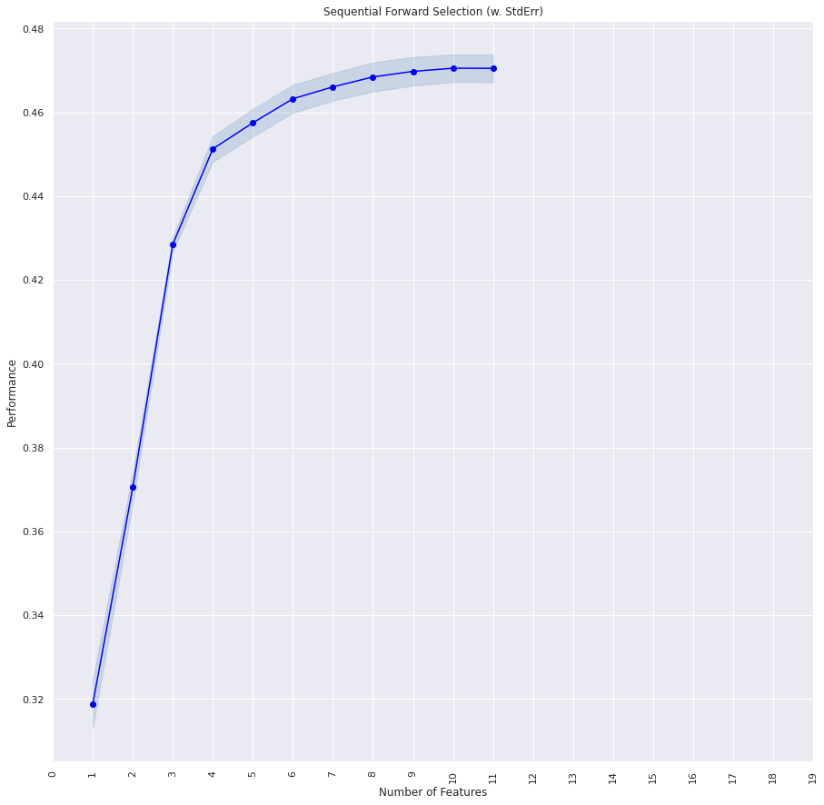

```python
# to plot the performance with addition of each feature
from sklearn.linear_model import LinearRegression

from mlxtend.plotting import plot_sequential_feature_selection as plot_sfs

fig1 = plot_sfs(sfs.get_metric_dict(), kind="std_err")
plt.title("Sequential Forward Selection (w. StdErr)")
plt.xticks(
    np.arange(0, 20, 1), np.arange(0, 20, 1), rotation=90
)  # to make the tick marks readable
plt.show()
```

```python
reg_sfs = LinearRegression()

# # Build step forward feature selection
sfs = SFS(
    reg_sfs,
    k_features=9,
    forward=True,
    floating=False,
    scoring="r2",
    cv=5,
)

# Perform SFFS
sfs = sfs.fit(x_train, y_train)
```

```python
# important features
feat_cols = list(sfs.k_feature_idx_)
print(feat_cols)
```

```
[0, 1, 2, 3, 4, 5, 6, 7, 10]
```

```python
x_train.columns[feat_cols]
```

```
Index(['accommodates', 'bathrooms', 'bedrooms', 'beds', 'review_score_log',
       'room_type_Private room', 'room_type_Shared room',
       'cancellation_policy_moderate', 'instant_bookable_t'],
      dtype='object')
```

```python
x_train_sfs = x_train[x_train.columns[feat_cols]]
```

```python
x_test_sfs = x_test[x_train_sfs.columns]
```

```python
# Fitting linear model
lin_reg_model_sfs = LinearRegression()
lin_reg_model_sfs.fit(x_train_sfs, y_train)

# let us check the coefficients and intercept of the model

coef_df = pd.DataFrame(
    np.append(lin_reg_model_sfs.coef_, lin_reg_model_sfs.intercept_.flatten()),
    index=x_train_sfs.columns.tolist() + ["Intercept"],
    columns=["Coefficients"],
)
coef_df
```

|  | Coefficients |
| --- | --- |
| accommodates | 0.083101 |
| bathrooms | 0.115484 |
| bedrooms | 0.174531 |
| beds | -0.051664 |
| review_score_log | 0.526199 |
| room_type_Private room | -0.487329 |
| room_type_Shared room | -1.040583 |
| cancellation_policy_moderate | -0.064869 |
| instant_bookable_t | -0.082952 |
| Intercept | 2.164312 |

```python
# model performance on train set
print("Training Performance:")
lin_reg_model_sfs_perf_train = model_performance_regression(
    lin_reg_model_sfs, x_train_sfs, y_train
)
lin_reg_model_sfs_perf_train
```

```
Training Performance:
```

|  | RMSE | MAE | R-squared | Adj. R-squared | MAPE |
| --- | --- | --- | --- | --- | --- |
| 0 | 0.560186 | 0.429834 | 0.47038 | 0.470245 | 9.011555 |

```python
# model performance on test set
print("Test Performance:")
lin_reg_model_sfs_perf_test = model_performance_regression(lin_reg_model_sfs, x_test_sfs, y_test)
lin_reg_model_sfs_perf_test
```

```
Test Performance:
```

|  | RMSE | MAE | R-squared | Adj. R-squared | MAPE |
| --- | --- | --- | --- | --- | --- |
| 0 | 0.560235 | 0.431901 | 0.461072 | 0.460751 | 9.065116 |